# Normal Distribution

Chad Worley

4/8/2020

## General Normal Distribution

Let $X$ be normally distributed with mean $\mu$ and standard deviation $\sigma$.
$$X \sim \mathcal{N}(\mu,\,\sigma)$$

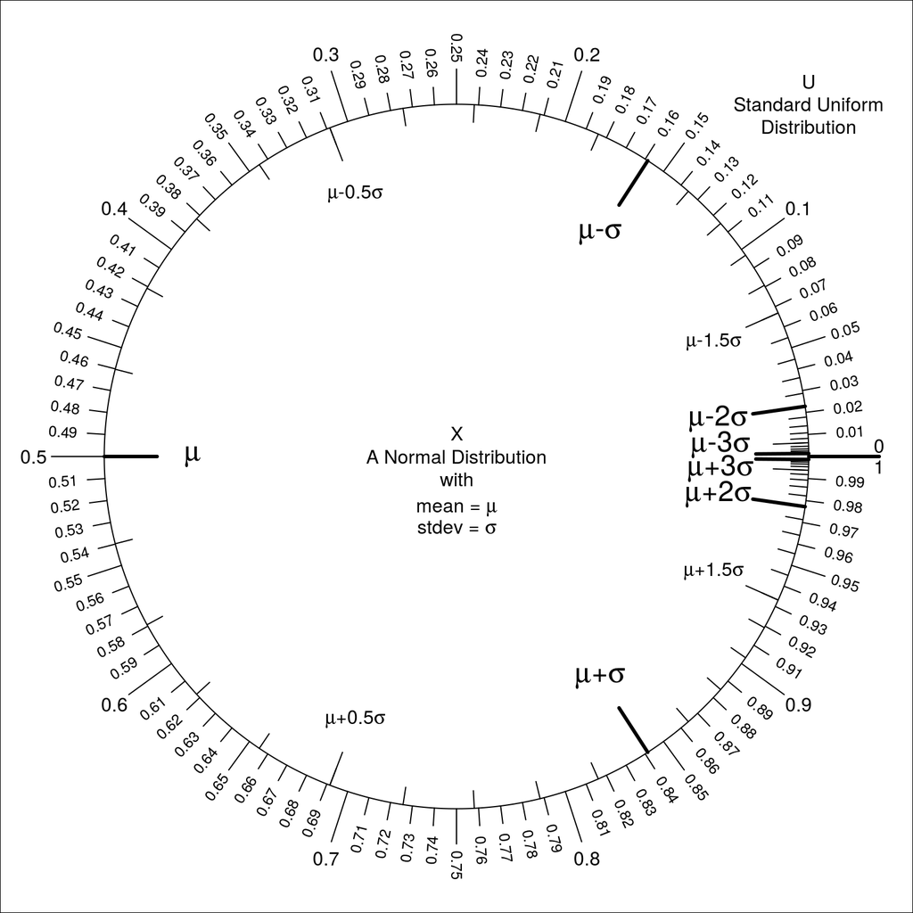

For any specific value $x$, like a boundary or single result, we can find a corresponding $z$-score.
$$z = \frac{x-\mu}{\sigma}$$

The probability that $X$ lands below $x$ can be found by using the corresponding $z$-score.
$$P(X<x) ~=~ P\left(Z<\frac{x-\mu}{\sigma}\right)$$
To determine the probability that $X$ lands over $x$:
$$P(X>x) ~=~ P\left(Z>\frac{x-\mu}{\sigma}\right)$$
When discussing central and two-tail probabilities of general normal distributions, it is helpful to introduce a new variable. I will use $d$ as the signed distance from mean to boundary. This is formally called the **deviation** from mean. https://en.wikipedia.org/wiki/Deviation_(statistics)
$$d = x-\mu$$

$$z = \frac{d}{\sigma}$$

To determine the probability that $X$ lands within $\mu-d$ and $\mu+d$.
$$P\left(\big|X-\mu\big|<d\right) ~=~ P\left(\big|Z\big|<\frac{d}{\sigma}\right)$$
To determine the probability that $X$ lands outside $\mu-d$ and $\mu+d$.
$$P\left(\big|X-\mu\big|>d\right) ~=~ P\left(\big|Z\big|>\frac{d}{\sigma}\right)$$
To determine probability that $X$ lands inside two arbitrary asymmetric boundaries $x_1$ and $x_2$.
$$P(x_1 < X < x_2) ~=~ P\left(\frac{x_1-\mu}{\sigma} < Z < \frac{x_2-\mu}{\sigma} \right)$$

Once you have translated the probability statement into a *standard* normal probability statement, you can use the techniques you have already practiced.

When determining boundaries from the probability, a little algebra is helpful.
$$x = \mu+z\sigma$$
$$d = z\sigma$$

## Example Normal Distribution

Let’s consider a normal distribution with a mean $\mu=100$ and a standard deviation $\sigma = 5$.
$$X \sim \mathcal{N}(100, \,5)$$

The spinner:

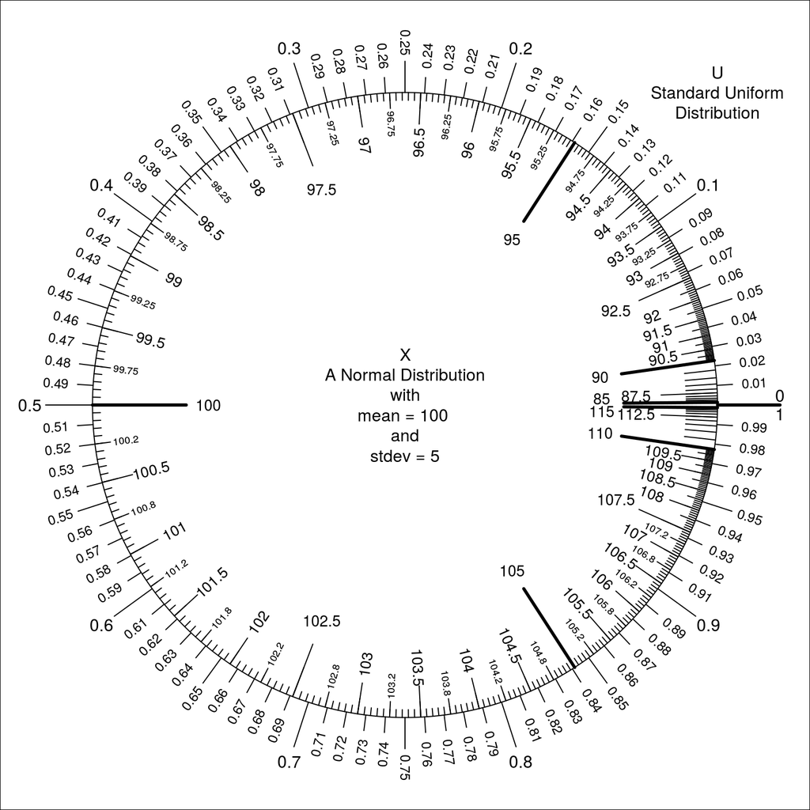

The density curve:

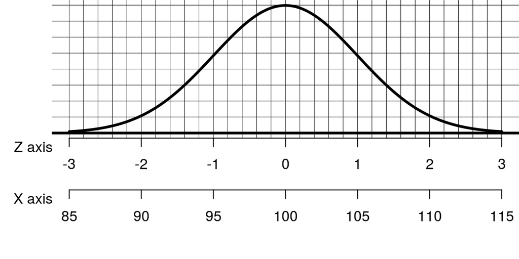

### Probability that $X$ lands UNDER $x$

Let’s consider a normal distribution with a mean $\mu=100$ and a standard deviation $\sigma = 5$.
$$X \sim \mathcal{N}(100, \,5)$$

Let’s pick an arbitrary boundary $x=95$. How would we calculate the probability that $X$ lands on a value less than 95?
$$P(X<95) = \,?$$

Well, we convert the boundary into a $z$ score.
$$\begin{aligned}
z &= \frac{x-\mu}{\sigma} \\ \\
&= \frac{95-100}{5} \\ \\
&= -1
\end{aligned}$$

So, we have rephrased the probability expression.
$$P(X<95) ~=~ P(Z<-1)$$

$$P(Z<-1) ~=~ \,?$$

Luckily for us, we know how to determine standard normal probabilities. This one just needs to be looked up on a $z$ table.
$$P(Z<-1) ~=~ 0.1587$$
Thus,
$$P(X<95) ~=~ 0.1587$$

Notice that on the spinner, if we shade the inner markings up to 95, the corresponding outer marking is approximately 0.159.

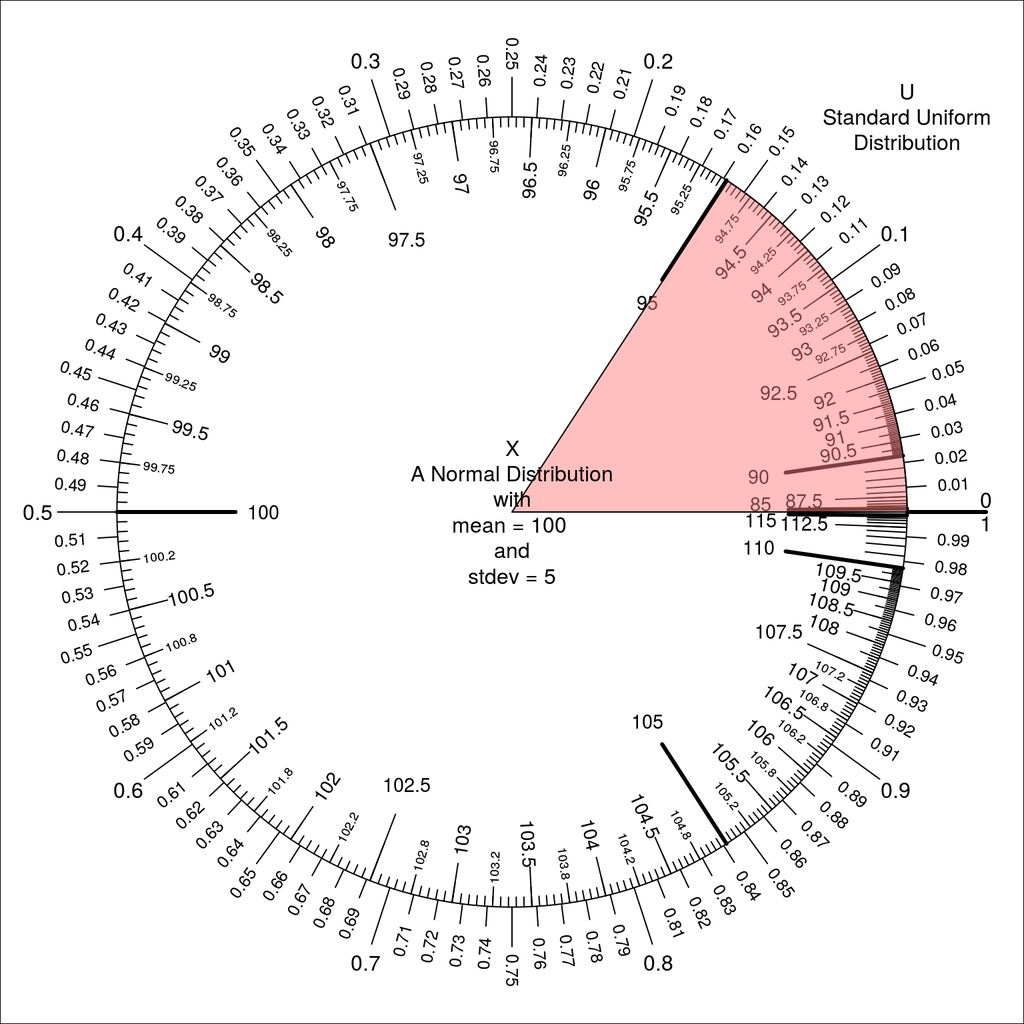

Notice if we shade under the density curve up to $x=95$, we shade approximately 16 percentage squares.

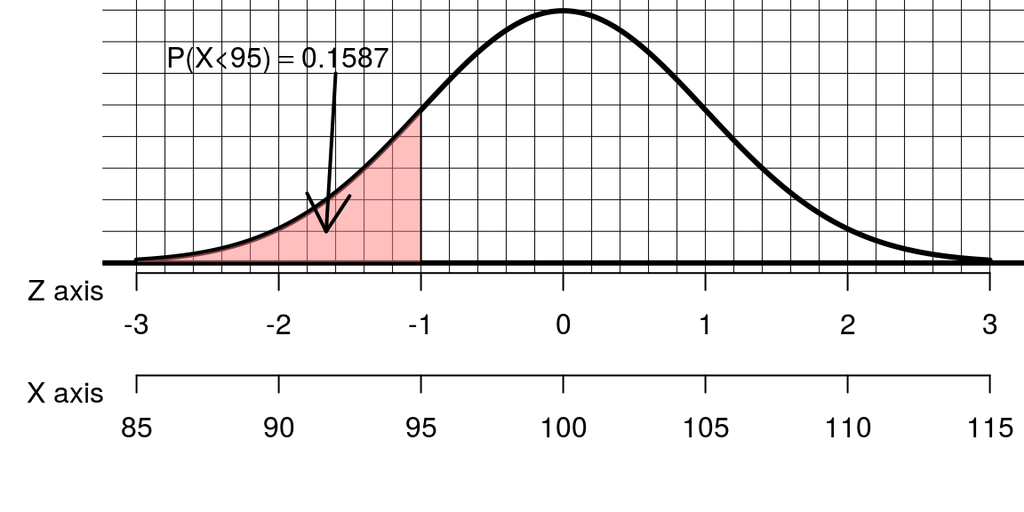

### Probability that $X$ lands OVER $x$

Let’s consider a normal distribution with a mean $\mu=100$ and a standard deviation $\sigma = 5$.
$$X \sim \mathcal{N}(100, \,5)$$

Let’s pick an arbitrary boundary $x=102$. How would we calculate the probability that $X$ lands on a value more than 102?
$$P(X>102) = \,?$$

Well, we convert the boundary into a $z$ score.
$$\begin{aligned}
z &= \frac{x-\mu}{\sigma} \\ \\
&= \frac{102-100}{5} \\ \\
&= 0.4
\end{aligned}$$

So, we have rephrased the probability expression.
$$P(X>102) ~=~ P(Z>0.4)$$

$$P(Z>0.4) ~=~ \,?$$

Luckily for us, we know how to determine standard normal probabilities.
$$P(Z>0.4) ~=~ 0.3446$$
Thus,
$$P(X>102) ~=~ 0.3446$$

Notice that on the spinner, if we shade the inner markings over 102, the corresponding outer markings are approximately 0.655 and 1. If we take a difference, we can estimate the probability. $1-0.655 = 0.345$. So, we see that about 34.5% of the circle is shaded.

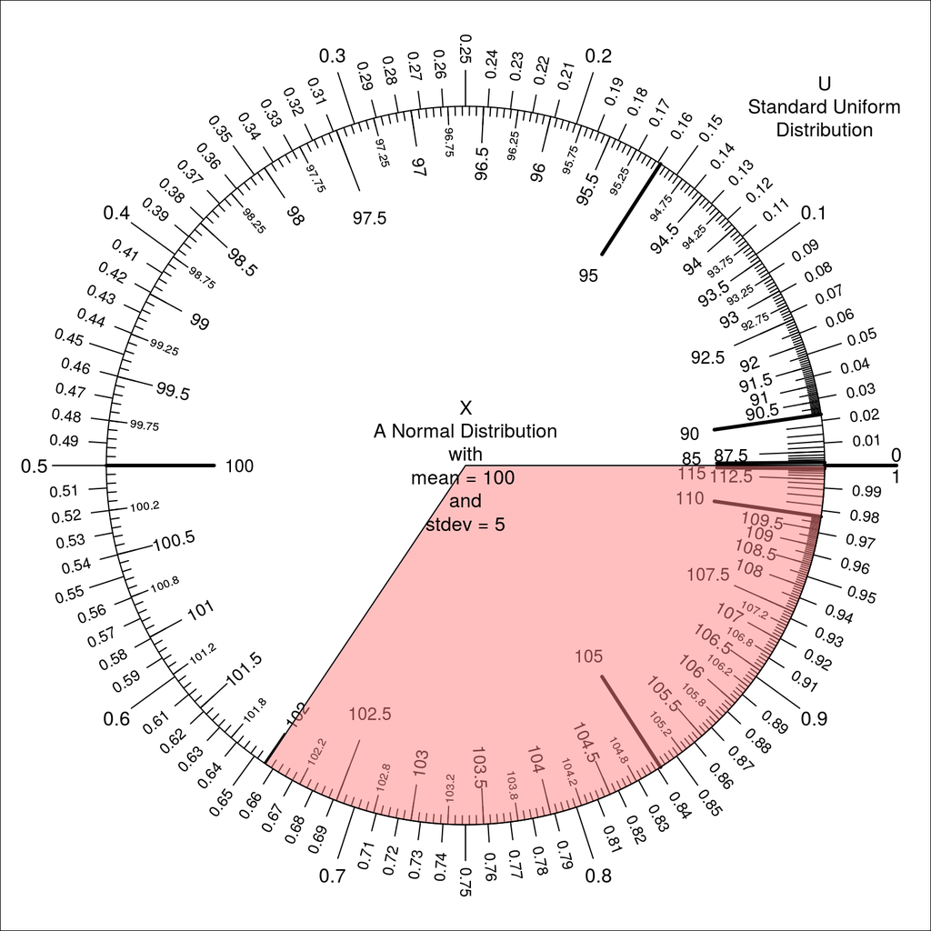

Notice if we shade the density curve where $x>102$, we shade approximately 34 percentage squares.

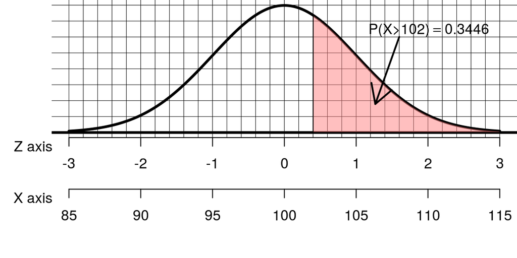

### Probability that $X$ lands near $\mu$

Let’s consider a normal distribution with a mean $\mu=100$ and a standard deviation $\sigma = 5$.
$$X \sim \mathcal{N}(100, \,5)$$

Let’s pick an arbitrary deviation $d=7$. Let’s pretend that we are interesting in the probability that $X$ is within $\pm7$ from $100$. In other words, what is the probability that $X$ is between $93$ and $107$?

$$P\left(\big|X-100\big|<7\right) ~=~ \,?$$

We rephrase this as a standard normal probability.
$$\begin{aligned}
z &= \frac{d}{\sigma} \\\\
&= \frac{7}{5} \\\\
&= 1.4
\end{aligned}$$

$$P\left(\big|X-100\big|<7\right) ~=~ P\left(\big|Z\big|<1.4\right)$$

$$P\left(\big|Z\big|<1.4\right) ~=~ ?$$

Luckily, we know how to find standard normal probabilities.
$$P\left(\big|Z\big|<1.4\right) ~=~ 0.8384$$

$$P\left(\big|X-100\big|<7\right) ~=~ 0.8384$$

### Probability that $X$ lands far from $\mu$

Let’s consider a normal distribution with a mean $\mu=100$ and a standard deviation $\sigma = 5$.
$$X \sim \mathcal{N}(100, \,5)$$

Let’s pick an arbitrary deviation $d=4$. Let’s pretend that we are interesting in the probability that $X$ is outside $\pm4$ from $100$. In other words, what is the probability that $X$ is outside the boundaries $96$ and $104$?

$$P\left(\big|X-100\big|>4\right) ~=~ \,?$$

We rephrase this as a standard normal probability.
$$\begin{aligned}
z &= \frac{d}{\sigma} \\\\
&= \frac{4}{5} \\\\
&= 0.8
\end{aligned}$$

$$P\left(\big|X-100\big|>4\right) ~=~ P\left(\big|Z\big|>0.8\right)$$

$$P\left(\big|Z\big|>0.8\right) ~=~ ?$$

Luckily, we know how to find standard normal probabilities.
$$P\left(\big|Z\big|>0.8\right) ~=~ 0.4238$$

$$P\left(\big|X-100\big|>4\right) ~=~ 0.4238$$

### Probability that $X$ lands between $x_1$ and $x_2$

Let’s consider a normal distribution with a mean $\mu=100$ and a standard deviation $\sigma = 5$.
$$X \sim \mathcal{N}(100, \,5)$$

Let’s pretend we want to know the probability that $X$ lands between $99$ and $108$.

First, draw a sketch. We can label the $X$ axis by adding integer multiples of 5 to 100. We know to shade the between $99$ and $108$ because those values satisfy the condition $99 < X < 108$.

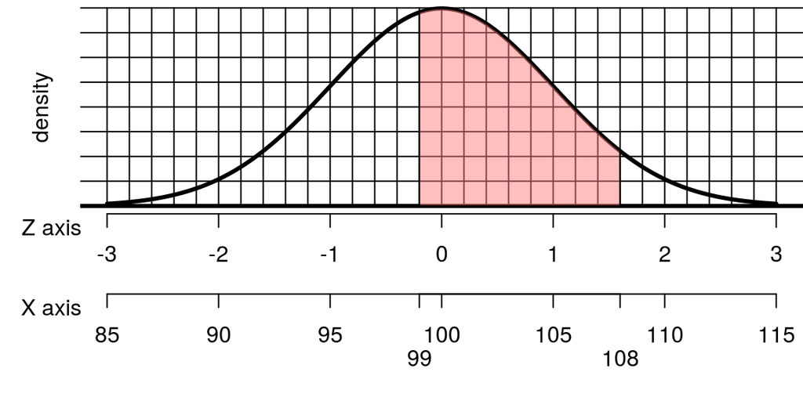

We calculate the $z$ values of the boundaries. Left boundary:
$$\begin{aligned}
z_1 &= \frac{x_1-\mu}{\sigma} \\\\
&= \frac{99-100}{5} \\\\
&= -0.2
\end{aligned}$$

Right boundary:

$$\begin{aligned}
z_2 &= \frac{x_2-\mu}{\sigma} \\\\
&= \frac{108-100}{5} \\\\
&= 1.6
\end{aligned}$$

We rephrase our problem into a **standard normal** probability problem:

$$P\left(99 < X < 108\right) ~=~ P(-0.2<Z<1.6)$$

So, we just need to evaluate $P(-0.2<Z<1.6)$.

From here we have a formula that lets us use the $z$ table. (We practiced this part before.)
$$\begin{aligned}
P(z_1 < Z < z_2) &= P(Z<z_2) - P(Z<z1) \\
P(-0.2<Z<1.6) &= P(Z<1.6)-P(Z<-0.2)\\
&= 0.9452-0.4207 \\
&= 0.5245
\end{aligned}$$

### Get $x$ from $P(X<x)$

Let’s consider a normal distribution with a mean $\mu=100$ and a standard deviation $\sigma = 5$.
$$X \sim \mathcal{N}(100, \,5)$$

Let’s pretend we want to determine a boundary such that $X$ lands below that boundary 72.57% of the time. In other words, let’s determine $x$ such that $P(X<x)=0.7257$.

We start by determining $z$ such that $P(Z<z)=0.7257$. We can do this by using the $z$ table.
$$P(Z<0.6) = 0.7257$$
So, we found the boundary as a $z$ score.
$$z=0.6$$
We calculate an associated $x$ boundary.
$$\begin{aligned}
x &= \mu+z\sigma \\
&= 100+(0.6)(5) \\
&= 103
\end{aligned}$$

So, we determined the boundary $x=103$.
$$P(X<103) ~=~ 0.7257$$

### Get $x$ from $P(X>x)$

Let’s consider a normal distribution with a mean $\mu=100$ and a standard deviation $\sigma = 5$.
$$X \sim \mathcal{N}(100, \,5)$$

Let’s pretend we want to determine a boundary such that $X$ lands above that boundary 96.41% of the time. In other words, let’s determine $x$ such that $P(X>x)=0.9641$.

We start by determining $z$ such that $P(Z>z)=0.9641$. We can do this by using the $z$ table after using the complement rule to recognize that $P(Z<z)=1-0.9641=0.0359$.
$$P(Z<-1.8) = 0.0359$$
So, we found the boundary as a $z$ score.
$$z=-1.8$$
We calculate an associated $x$ boundary.
$$\begin{aligned}
x &= \mu+z\sigma \\
&= 100+(-1.8)(5) \\
&= 91
\end{aligned}$$

So, we determined the boundary $x=91$.
$$P(X>91) ~=~ 0.9641$$

### Get $d$ from $P(|X-\mu|<d)$. Also, report $\mu-d$ and $\mu+d$.

Let’s consider a normal distribution with a mean $\mu=100$ and a standard deviation $\sigma = 5$.
$$X \sim \mathcal{N}(100, \,5)$$

In other words, we want to find two boundaries equally far from the mean such that $X$ lands between them $31.08\%$ of the time.

### Get $d$ from $P(|X-\mu|>d)$. Also, report $\mu-d$ and $\mu+d$.

Let’s consider a normal distribution with a mean $\mu=100$ and a standard deviation $\sigma = 5$.
$$X \sim \mathcal{N}(100, \,5)$$

In other words, we want to find two boundaries equally far from the mean such that $X$ lands between them $76.98\%$ of the time.